# Introduction to R

## Overview and History of R

- R is a dialect of the S language.
- S is a language that was developed by John Chambers and others at Bell Labs. S was initiated in 1976
- R was created in 1991 – by Rose Ihaka and Robert Gentleman
- In 1993 R was released to the public. 1997: R core group was formed 2000: R 1.0.0 was released
- We are using R version 4.* (202*)

## Features of R

- Runs on almost any standard computing platform/OS (even on the PlayStation 3)
- Frequent releases (annual + bug_x releases); active development.
- Useful for interactive work, but contains a powerful programming language for developing new tools (user –> programmer)

## Feature of R

- Very active and vibrant user community;
  - R-help
  - R-devel mailing lists
  - Stack Overflow – look at them on when at R help
- It’s free! (Both in the sense of beer and in the sense of speech.)

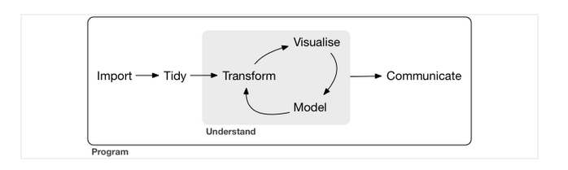

Data Science and R

## Setup local environment

- Download R from - The Comprehensive R Archive Network -http://cran.r-project.org/ and R Studio
- Available for the key OS

**R-studio?** -RStudio is the premier integrated development environment for R. - Download and install from http://www.rstudio.com/

**Why R-studio?** - RStudio’s source editor includes a variety of productivity enhancing features including syntax highlighting, code completion, multiple-file editing, and find/replace, retrieving prev commands

## Sometimes it is tricky …

- R can be tricky to learn,
- feel free to contact/tweet/IG/DM any of the demonstrators with questions
- *please make sure that you have thought through your question in advance*
- *R problems can be solved with judicious use of Google and StackOverFlow*

## Help Areas

- R Help Mailing List - https://stat.ethz.ch/mailman/listinfo/r-help
- R CookBook - http://www.cookbook-r.com/
- R-Bloggers - http://www.r-bloggers.com/
- Stack overflow About R - http://stackoverflow.com/tags/r/info
- Stack overflow R FAQ - http://stackoverflow.com/tags/r
- R google group - https://groups.google.com/forum/#!forum/r-help-archive
- https://exeter-data-analytics.github.io/IntroToR/

## Types of people in the world

- *There are **10 types of people** in this world, those who understand binary and those who dont*

## The Terms

- **Object** R is an object oriented language and everything in R is an object.
  - We store using `<-` operator ie `x <- 3`
- **Function** A set of instructions carried out on one or more objects.
  - function *mean()* is used to calculate the arithmetic mean.
- **Vector** A collection of one or more objects of the same type . We use `c()`
- **Operator** Is a symbol that has a pre-defined meaning. +*-/
- **Parameter** The kind of information that can be passed to a function – mean(age)

## Packages

- A set of functions designed to perform more specific statistical or graphical tasks examples and documentation.
- 17000+ packages found on the CRAN
- To use packages in R, download using `install.packages()`

## Data Types / Classes

| Data Types | Stores |
| --- | --- |
| real | floating point numbers |
| integer | integers |
| complex | Complex numbers |
| factor | categorical data |
| character | strings |
| logical | TRUE or FALSe |
| NA | Missing |
| NULL | Empty |
| Function | Function type |

## RStudio Platform

[figure not shown]

RSTUDIO

## Vector

- A vector can only contain objects of the same class

```r
# numeric vector
a <- c(1,2,5.3,6,-2,4)
# character vector
b <- c("one","two","three")
#logical vector
c <- c(TRUE,TRUE,TRUE,FALSE,TRUE,FALSE)
```

## Factors

- Used to represent categorical data.
- Can be unordered or ordered. -A factor is like an integer vector where each integer has a label.

```r
# A factor variable
  x <- factor(c("yes", "yes", "no", "yes", "no"))
  x
```

```
## [1] yes yes no  yes no
## Levels: no yes
```

## Data Frames

- More general than a matrix, has different columns and can have different modes (numeric, character, factor, etc.)
- Used to store tabular data
- Can store data of different classes
- *read_._table()* or *read_._csv()* – used to load `data.frames`

## Create Data Frames

```r
## create a data frame
## create vector x
x <- c(1, 2,3,4,5,6,7,8,9)
# create vector y
y <- c("a","b","c","d","e","f","g","h","i")
# combine them to a data frame df
df <- data.frame(x=x, y=y)
```

```r
# view the contents of a data frame
print(df)
```

```
##   x y
## 1 1 a
## 2 2 b
## 3 3 c
## 4 4 d
## 5 5 e
## 6 6 f
## 7 7 g
## 8 8 h
## 9 9 i
```

```r
# check the structure of the data frame
str(df)
```

```
## 'data.frame':    9 obs. of  2 variables:
##  $ x: num  1 2 3 4 5 6 7 8 9
##  $ y: chr  "a" "b" "c" "d" ...
```

## Datasets

- R works with different types of datasets
- Base R functions *read.table* and *read_._csv* can read in data stored as text files, delimited by *almost anything*
- Data from other statistics tools can be read using
  - `readxl` - for excel datasets
  - `haven` - for Stata files
  - `foreign` - for other files like SPSS

#### Task

Install the `readxl`, `haven` and `foreign` package

#### Solution

```r
install.packages('readxl')
install.packages('haven')
install.packages('foreign')
```

## Creating an analysis project - Ideal Way

- Using R Studio to create a Project - From an existing directory

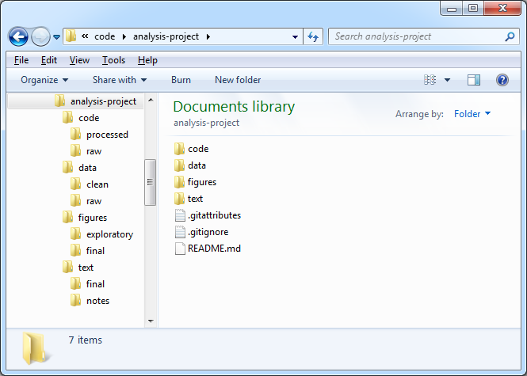